# Rogers_HW9

Alex Rogers

10/18/2021

### Chapter 8 Practice

```r
library(bayesrules)
library(tidyverse)
library(rstan)
```

```r
library(bayesplot)
library(broom.mixed)
library(janitor)
data("moma_sample")
```

```r
moma_sample |>
  group_by(genx) |>

  tally()
```

```
## # A tibble: 2 x 2
##   genx      n
##   <lgl> <int>
## 1 FALSE    86
## 2 TRUE     14
```

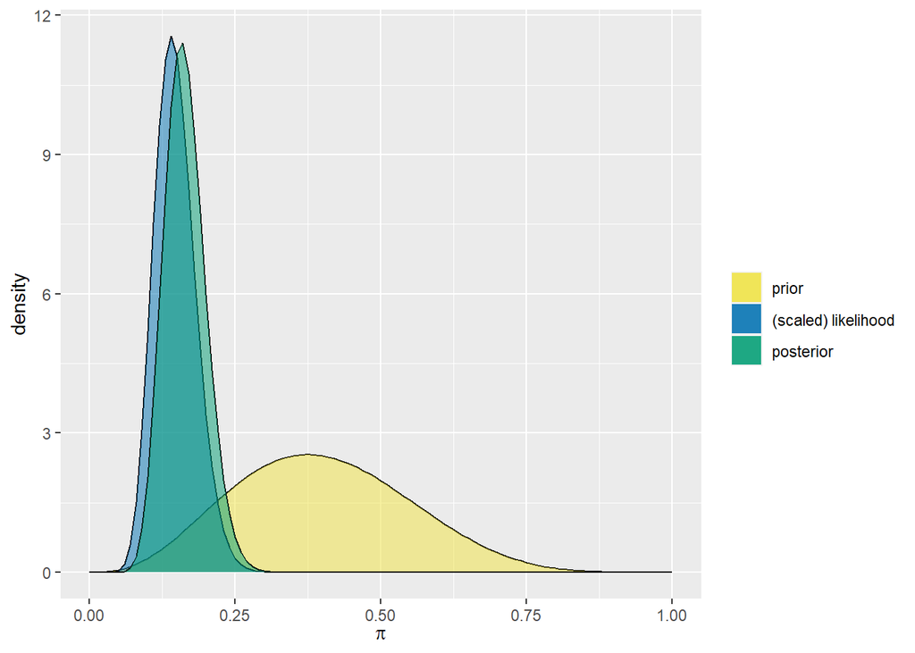

```r
plot_beta_binomial(4, 6, 14, 100)
```

```r
summarize_beta_binomial(4, 6, 14, 100)
```

```
##       model alpha beta      mean      mode         var         sd
## 1     prior     4    6 0.4000000 0.3750000 0.021818182 0.14770979
## 2 posterior    18   92 0.1636364 0.1574074 0.001232969 0.03511365
```

```r
qbeta(c(.025, .975), 18, 92)
```

```
## [1] 0.1009084 0.2379286
```

```r
qbeta(c(.25, .75), 18, 92)
```

```
## [1] 0.1388414 0.1862197
```

```r
qbeta(c(.005, .995), 18, 92)
```

```
## [1] 0.08530422 0.26468037
```

### 8.2 Hypothesis Testing

```r
post_prob <- pbeta(.2, 18, 92)

post_odds <- post_prob / (1 - post_prob)
```

```r
prior_prob <- pbeta(.2, 4, 6)

prior_odds <- prior_prob / (1 - prior_prob)
```

```r
BF <- post_odds / prior_odds
```

### 8.4 Posterior analysis with MCMC

```r
art_model <- "data {

  int<lower = 0, upper = 100> Y;


}

parameters {

  real<lower = 0, upper = 1> pi;

}

model {

  Y ~ binomial(100, pi);

  pi ~ beta(4, 6);

}"
```

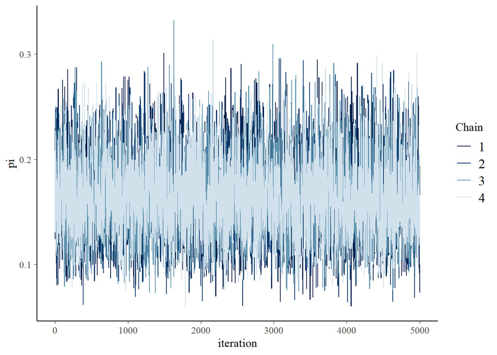

```r
art_sim <- stan(model_code = art_model, data = list(Y = 14),
                chains = 4, iter = 5000*2)
# visual diagnostics

mcmc_trace(art_sim, pars = "pi", size = .5) +
  xlab("iteration")
```

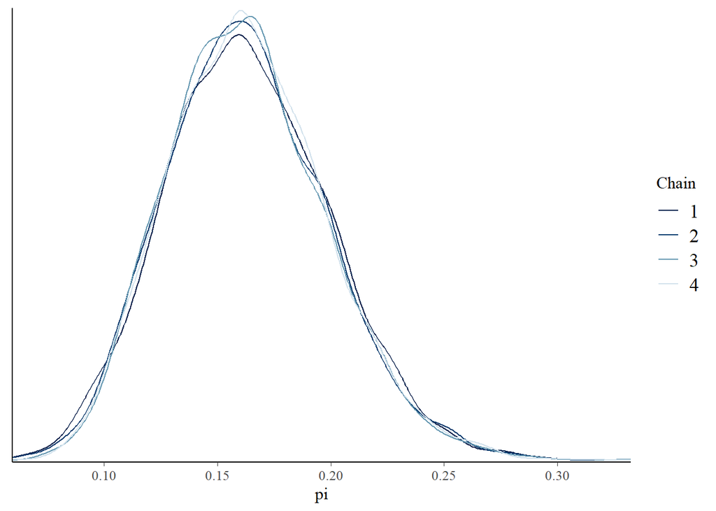

```r
mcmc_dens_overlay(art_sim, pars = "pi")
```

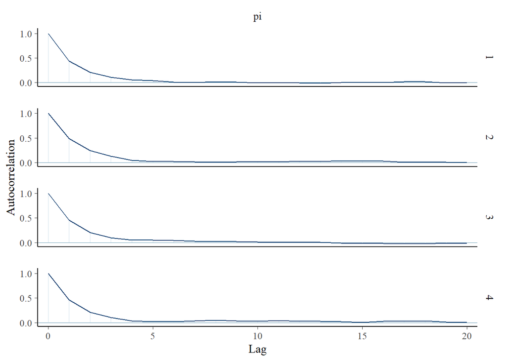

```r
mcmc_acf(art_sim, pars = "pi")
```

```r
# data diagnostics

rhat(art_sim, pars = "pi")
```

```
## [1] 1.000489
```

```r
neff_ratio(art_sim, pars = "pi")
```

```
## [1] 0.3187117
```

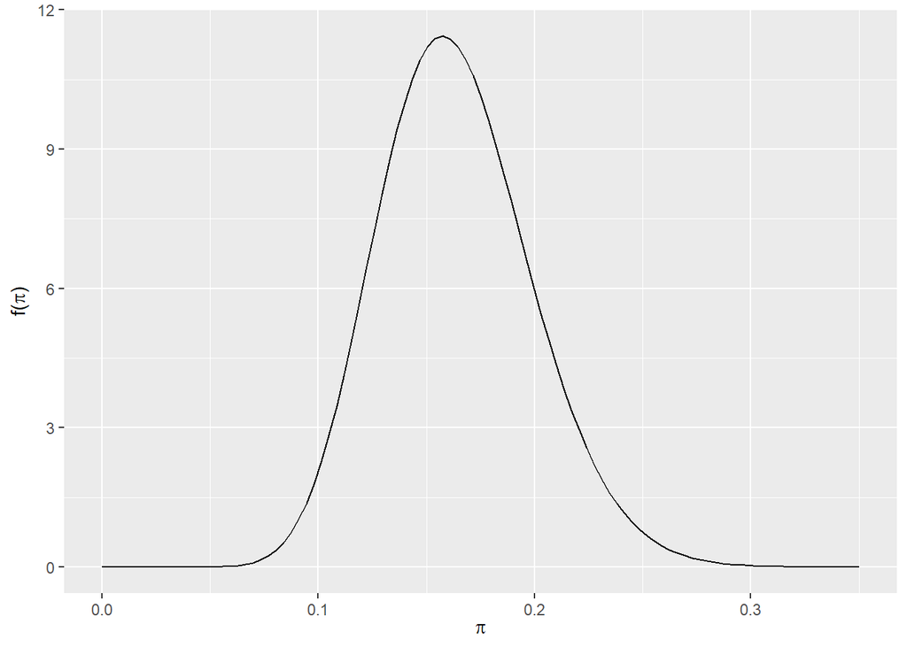

```r
plot_beta(18, 92)+
  lims(x = c(0, .35))
```

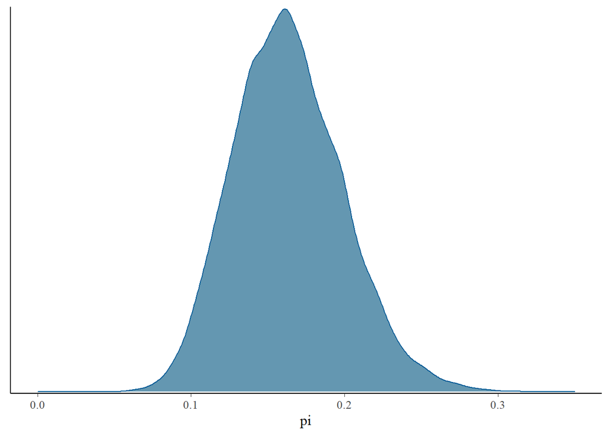

```r
mcmc_dens(art_sim, pars = "pi")+
  lims(x = c(0, 0.35))
```

```r
tidy(art_sim, conf.int = TRUE, conf.level = .95)
```

```
## # A tibble: 1 x 5
##   term  estimate std.error conf.low conf.high
##   <chr>    <dbl>     <dbl>    <dbl>     <dbl>
## 1 pi       0.162    0.0354    0.100     0.238
```

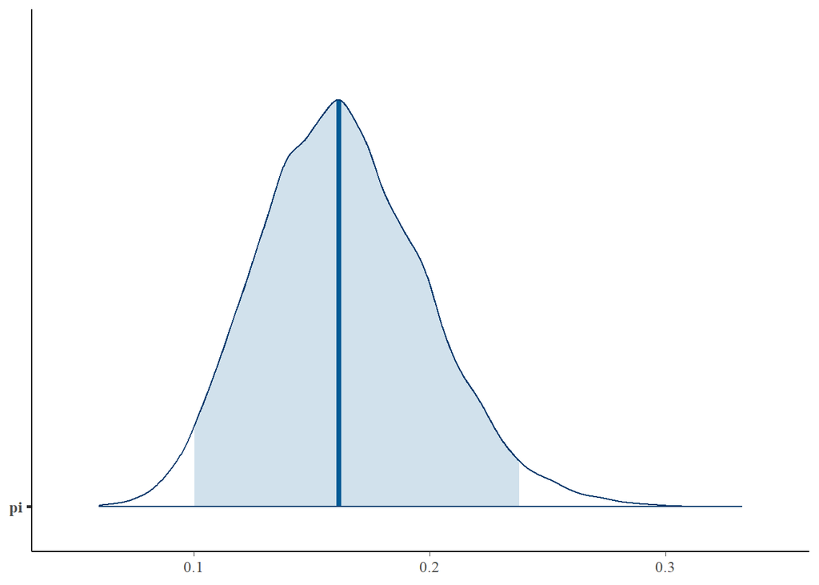

```r
mcmc_areas(art_sim, pars = "pi", prob = .95)
```

```r
# storing the four chains as one data frame

art_chains_df <- as.data.frame(art_sim, pars = "lp__", #what is "lp__"?
                               include = FALSE)
dim(art_chains_df)
```

```
## [1] 20000     1
```

```r
# calculating posterior summaries of pi

art_chains_df |>
  summarize(post_mean = mean(pi),
            post_median = median(pi),
            post_mode = sample_mode(pi),
            lower_95 = quantile(pi, .025),
            upper_95 = quantile(pi, .975))
```

```
##   post_mean post_median post_mode  lower_95  upper_95
## 1  0.163424   0.1615623 0.1612047 0.1002144 0.2380038
```

```r
art_chains_df |>
  mutate(exceeds = pi < .2) |>
  tabyl(exceeds)
```

```
##  exceeds     n percent
##    FALSE  2995 0.14975
##     TRUE 17005 0.85025
```

### Posterior Prediction

```r
art_chains_df <- art_chains_df |>
  mutate(y_predict = rbinom(length(pi),
                            size = 20,
                            prob = pi))
```

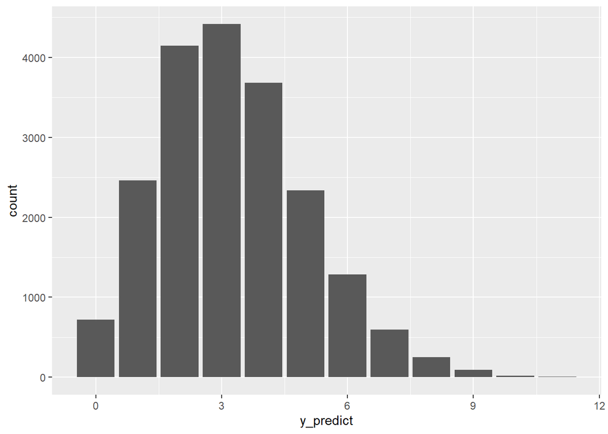

```r
ggplot(art_chains_df, aes(x = y_predict))+
  stat_count()
```

```r
art_chains_df |>
  summarize(mean = mean(y_predict),
            lower_80 = quantile(y_predict, .1),
            upper_80 = quantile(y_predict, .9))
```

```
##     mean lower_80 upper_80
## 1 3.2666        1        6
```

### 8.7 Exercises

##### Exercise 8.1 (Posterior Analysis)

Three common tasks in a posterior analysis are:

1. Posterior estimation, which gives us a range of plausible values for pi
2. Posterior hypothesis testing, where we can calculate the posterior probability given our null or alternative hypothesis
3. Posterior prediction, which allows us to predict the outcome of some new data, given sampling variability and posterior variability in pi.

##### Exercise 8.2 (Warming up)

1. In just reporting the central tendency, we don’t get a sense of the variability in theta, thus our certainty is undefined.
2. I interpret this as that an expectation that 95% of values of theta here are between 1 and 3.4

##### Exercise 8.3 (Hypothesis testing?)

This question is a bit confusing to interpret for me. It seems that the only situation in which data were collected is scenario d. Because we need to calculate posterior probability and posterior odds in order to asses the Bayes Factor and test the hypothesis, scenario d seems to be the only one where hypothesis testing is a valid option.

##### Exercise 8.4 (Bayes Factor)

1. Posterior odds is a measure of how much more likely pi is to be above or below a hypothesizes value, measured as a ratio:

the probability of our hypothesized value of pi given the data / the probability of the nullly hypothesized value of pi given the data

2. Prior odds is a ratio which represents how much more likely our alternate hyptothesis is compared to the null hypothesis, because it is prior, it does not include a value of Y, and is:

probability of alternative hypothesis / probability of null hypothesis

3. Bayes factor is a ratio which determines how much more likely our posterior odds are compared to the prior odds:

posterior odds / prior odds

The larger Bayes factor, the more convinced we are of our hyptothesis!

##### Exercise 8.5 (Posterior prediction: concepts)

1. Posterior predictive models incorporate variability regarding sampling, as well as the variability of the potential posterior values of pi.

In layperson’s terms, posterior predictive models allow us to make a prediction of what data we might see in a given sample, taking into consideration that sometimes in sampling we might randomly get unrepresentative values, and also that though we have some idea of what to expect based on prior information, we aren’t certain about those expectations, and so leaving room for unceratinty is healthy.

2. A real life situation where posterior prediction would be helpful: Maybe in a political campaign, where you have the number of people who have voted in previous elections, and you want to get an idea of how many might vote in future elections.
3. The posterior predictive model is dependent on both the data (sampling variability) and the parameter (posterior variability built from prior pi).

#### Exercise 8.6 (Credible intervals: Part I)

For each situation, find the appropriate credible interval using the "middle approach

```r
qbeta(c(.025, .975), 4, 5)
```

```
## [1] 0.1570128 0.7551368
```

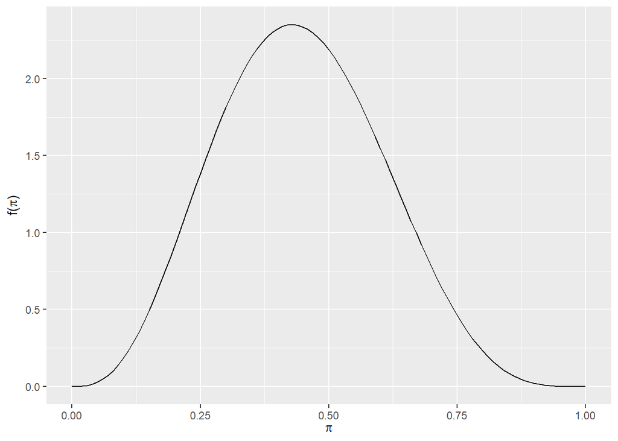

```r
plot_beta(4, 5) # plotting to check intuitiveness
```

The plot represents the data, about 95% of values fall between .16 and .75

```r
qbeta(c(.2, .8), 4 , 5)
```

```
## [1] 0.3032258 0.5836554
```

```r
#95 % credible interval for theta with Gamma (1, 8)

qgamma(c(.025, .975), 1, 8)
```

```
## [1] 0.003164726 0.461109932
```

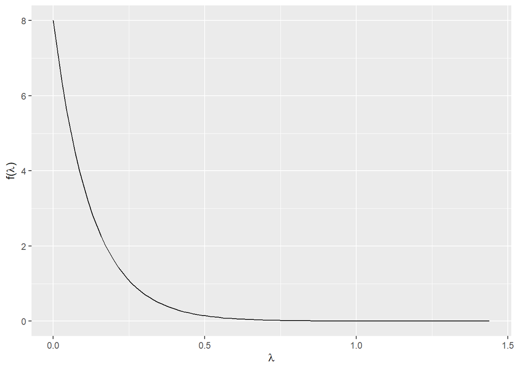

```r
plot_gamma(1, 8)
```

##### Exercise 8.7 (Credibile intervals: Part II)

```r
#99% credible interval for theta with Gamma(1, 5)

qgamma(c(.005, .995), 1, 5)
```

```
## [1] 0.001002508 1.059663473
```

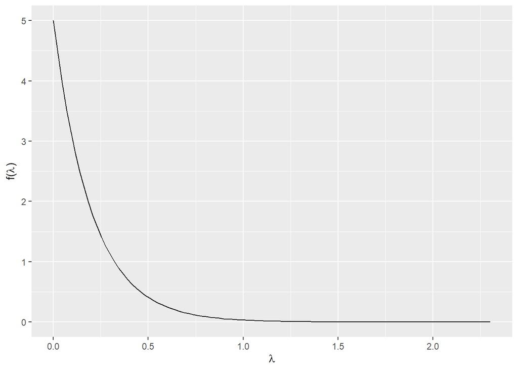

```r
plot_gamma(1, 5)
```

```r
#95% credible interval for mu with Normal(10, 2^2)

qnorm(c(.025, .975), 10, 2)
```

```
## [1]  6.080072 13.919928
```

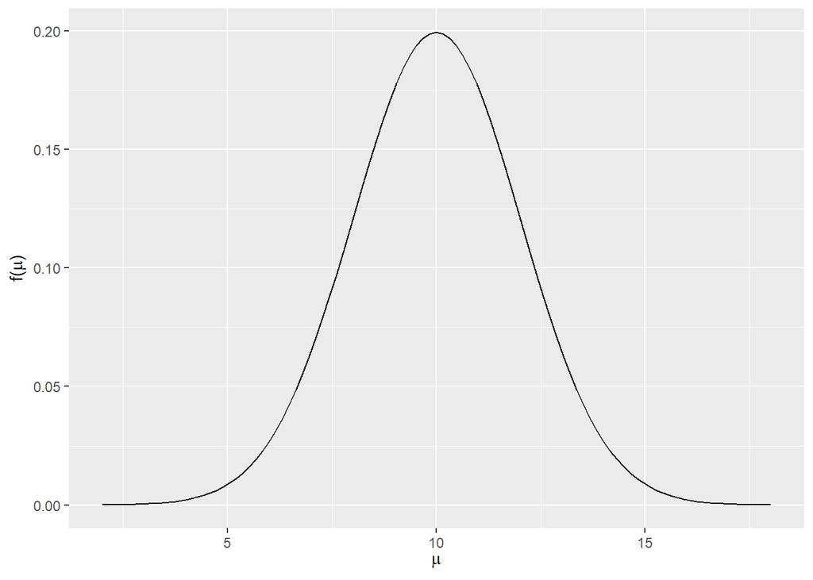

```r
plot_normal(10, 2)
```

```r
# 80% credible interval for mu with Normal(-3, 1^2)

qnorm(c(.1, .9), -3, 1)
```

```
## [1] -4.281552 -1.718448
```

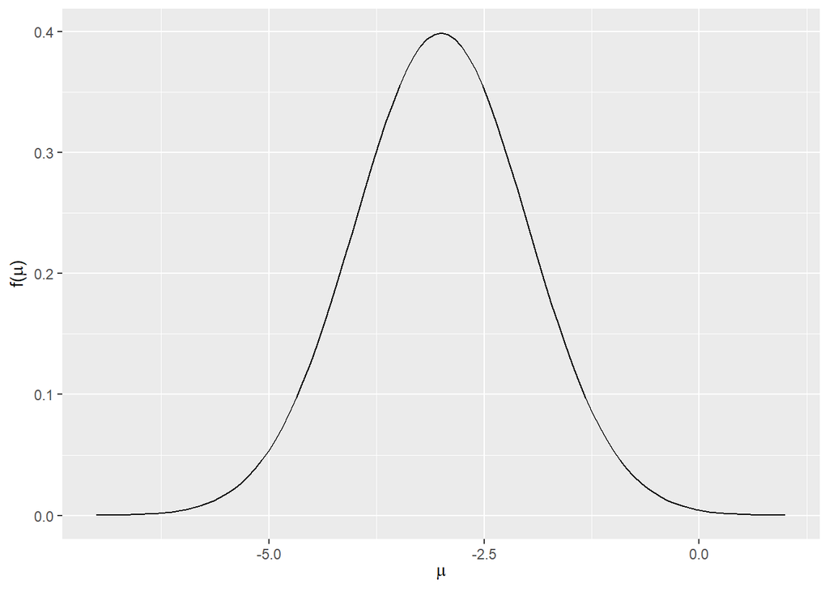

```r
plot_normal(-3, 1)
```

##### Exercise 8.8 (Credible intervals: highest posterior density)

```r
#highest posterior density interval for gamma (1, 5)

qgamma(c(.05, 1), 1, 5)
```

```
## [1] 0.01025866        Inf
```

```r
# this is what my intuition tells me but is obviously wrong. Asking the cohort for help. Frustratingly, the chapter says "we won't worry about how to do this now, it'll come up in the exercises, but doesn't say how to do it.
```

Okay so I was on the right track but had it backwards. Still don’t know how we’re supposed to just know this.

```r
qgamma(c(0, .95), 1, 5)
```

```
## [1] 0.0000000 0.5991465
```

```r
# middle 95% for Gamma(1,5)
qgamma(c(.025, .975), 1, 5)
```

```
## [1] 0.005063562 0.737775891
```

Compare the intervals from a and b.

The 95% highest interval seem a more preceise measurement here

```r
# 95% highest posterior density credible interval for normal(-13, 2^2)


qnorm(c(0, .95), -13, 2)
```

```
## [1]      -Inf -9.710293
```

The same approach doesn’t work here. I think that makes sense because a normal distribution could stretch to negative infinity. I don’t exactly know how to correct for this.

```r
# middle 95% posterior density credible interval for normal(-13, 2^2)

qnorm(c(.025, .975), -13, 2)
```

```
## [1] -16.919928  -9.080072
```

Since this is a normal distribution, shouldn’t this be… well, normally distributed. Is looking at the high 95% even helpful (or possible?)

##### Exercise 8.9 (Hypothesis tests: Part I)

Prior : Beta(1, .8) Posterior : Beta(4, 3)

```r
pbeta(.4, 4, 3)
```

```
## [1] 0.1792
```

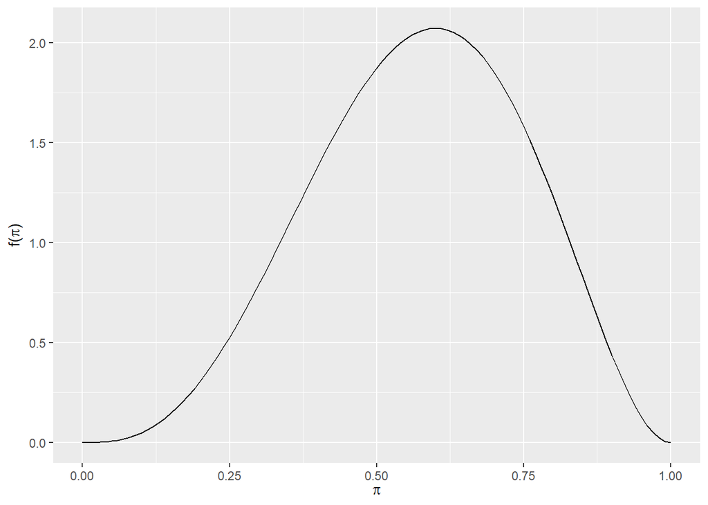

```r
plot_beta(4, 3)
```

I think this is the probability of the null hypothesis. So if I’m right about that the posterior probability for the alternative hypothesis would be

```r
nullhyp <- pbeta(.4, 4, 3)
althyp <- 1 - nullhyp
althyp
```

```
## [1] 0.8208
```

I think this makes sense given the skew of the plot?

Calculate and interpret the posterior odds

```r
postodds <-
althyp / nullhyp

postodds
```

```
## [1] 4.580357
```

It is about 4.6 times more likely that the alternate hypothesis is true as compared to the null hypothesis

Calculate and interpret the prior odds

```r
prior_prob <- pbeta(.4, 1, .8)
prior_prob
```

```
## [1] 0.3354602
```

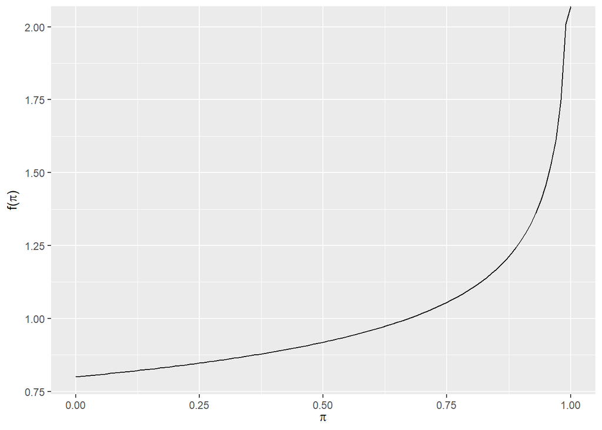

```r
plot_beta(1, .8)
```

```r
# I don't know that this one follows intuition. Is this not checking for the probability that pi is .4 or lower? This feels like it should be much smaller than .3
```

```r
prior_odds <- prior_prob / (1 - prior_prob)
prior_odds
```

```
## [1] 0.5048008
```

```r
# I'm following what's laid out in the chapter, but it feels like this equation should be inverted. I'm worried I've mixed something up
```

It is about .5 as likely that the alternate hypothesis is true as compared to the null

Calculate and interpret the Bayes Factor

```r
bf <- post_odds / prior_odds
bf
```

```
## [1] 11.13684
```

A Bayes factor of 11 indicates that the posterior odds of our hypothesis is about 11 times that of the prior odds. That seems good, but not great?

5. I’m not sure that I have everything in the right place, but if I do, I would interpret this as, we have some evidence that the alternative hypothesis is true, but I want more information.

##### Exercise 8.10 (Hypothesis tests: Part I)

For parameter mu:

prior: N(10, 10^2)

posterior: N(5, 3^2)

Testing for H0 mu >= 5.2 versus Ha mu < 5.2

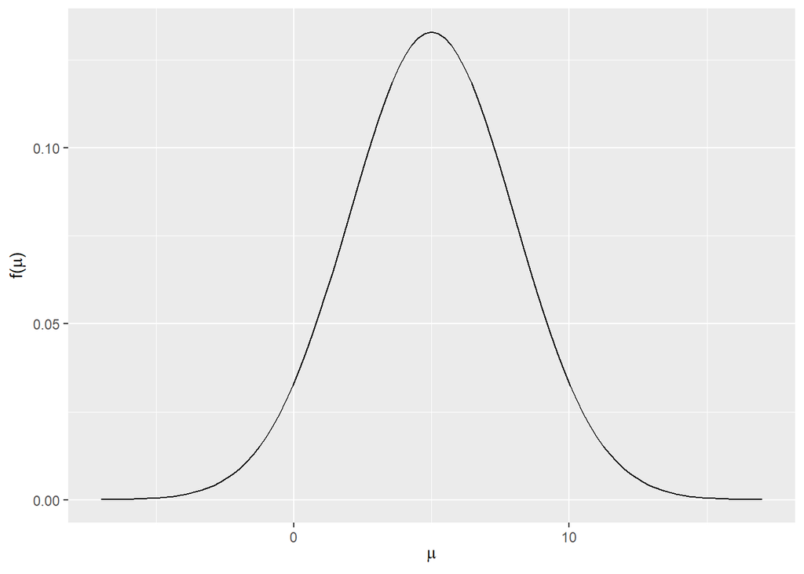

```r
# posterior probability that mu < 5.2

post_prob <- pnorm(5.2, 5, 3)
plot_normal(5, 3)
```

```r
post_prob
```

```
## [1] 0.5265765
```

```r
post_odds <- post_prob / (1 - post_prob)
post_odds
```

```
## [1] 1.112274
```

```r
prior_prob <- (1 - pnorm(5.2, 10, 10))
    # I'm using 1 - here because if pnorm(5.2, 10, 10) gives the probability      that mu < 5.2, I want the opposite. Is this right?

prior_prob
```

```
## [1] 0.6843863
```

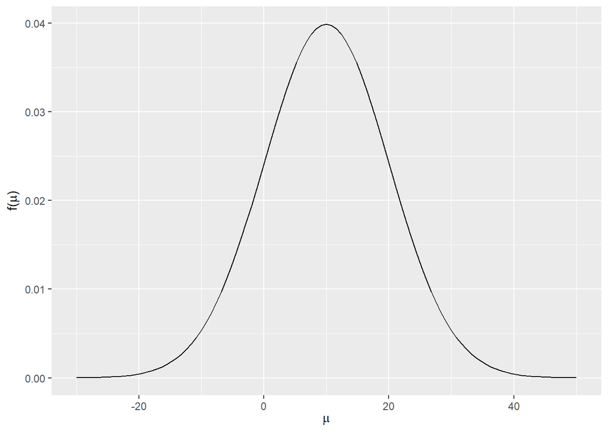

```r
plot_normal(10, 10)
```

```r
# I think it's intuitive given the plot.
```

```r
prior_odds <- (1 - prior_prob) / prior_prob
prior_odds
```

```
## [1] 0.4611631
```

Calculate Bayes Factor

```r
post_odds / prior_odds
```

```
## [1] 2.411888
```

We have a bit of evidence in favor of the hypothesis but it is not very convincing.

### 8.7.3 Applied exercises

##### Exercise 8.14 (Climate change: estimation)

1. The beta-binomial model is appropriate here because we’re dealing with a binomial variable (believers vs not)

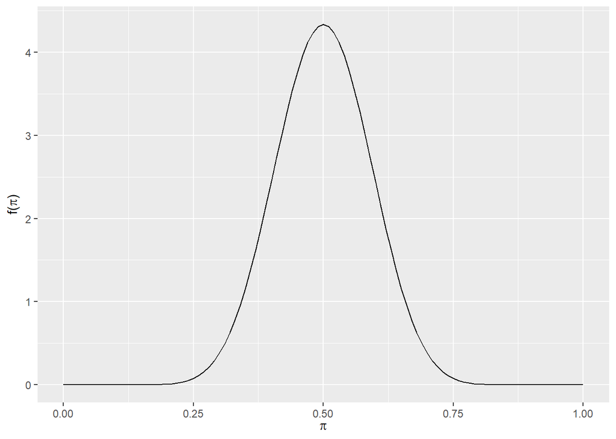

```r
plot_beta(15, 15)
```

I think that about half of the population of the US doesn’t believe in climate change (a political line), maybe between 40% and 60%

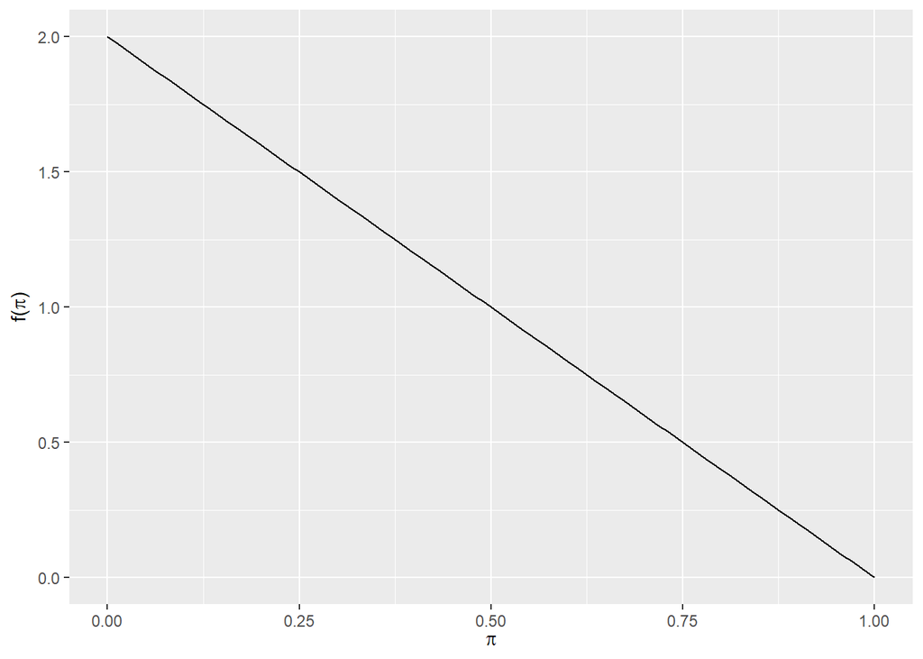

```r
plot_beta(1, 2)
```

I think it’s about 50/50

The authors think that basically it’s more likely that people do believe in climate change but don’t but they’re not very sure at all.

```r
data("pulse_of_the_nation")


nonbelievers <- filter(pulse_of_the_nation, climate_change == "Not Real At All")

sample <- nonbelievers |> nrow()
total <- pulse_of_the_nation |> nrow()

sample / total
```

```
## [1] 0.15
```

```r
summarize_beta_binomial(1, 2, 150, 1000)
```

```
##       model alpha beta      mean      mode          var         sd
## 1     prior     1    2 0.3333333 0.0000000 0.0555555556 0.23570226
## 2 posterior   151  852 0.1505484 0.1498501 0.0001273741 0.01128601
```

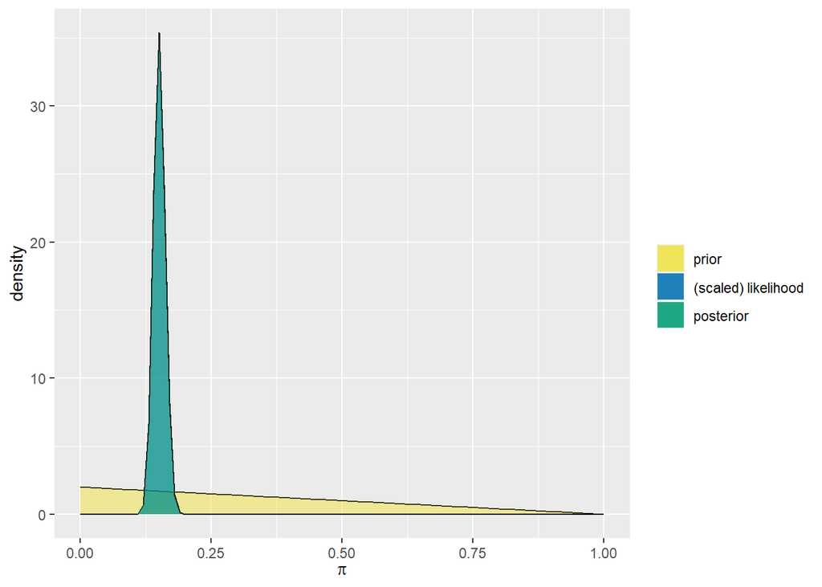

```r
plot_beta_binomial(1, 2, 150, 1000)
```

```r
qbeta(c(.025, .975), 151, 852)
```

```
## [1] 0.1291000 0.1733164
```

Given the data and our weak prior, we are very confident that the middle 95% of pi values exist between .13 and .17

##### Exercise 8.15 (Climate change: hypothesis testing)

The alternate hypothesis that pi > .1 seems logical given that the lowest value on the CI is > .13

```r
# posterior probability that pi > .1

post_prob <- 1 - pbeta(.1, 151, 852)
post_prob
```

```
## [1] 0.9999997
```

Makes sense I think. Given the data we’re near certain pi > .1

```r
# calculate and interpret Bayes Factor for the hypothesis test

post_odds <- post_prob / (1- post_prob)
post_odds
```

```
## [1] 3197444
```

```r
prior_prob <- 1 - pbeta(.1, 1, 2)
prior_prob
```

```
## [1] 0.81
```

```r
prior_odds <- prior_prob / (1 - prior_prob)
prior_odds
```

```
## [1] 4.263158
```

```r
bf <- post_odds / prior_odds
bf
```

```
## [1] 750017.6
```

We have a very powerful Bayes Factor of over 75000

This result make sense, the hypothesis is almost certainly correct given what we learned from the CI and the Bayes Factor.

##### Exercise 8.16 (Climate change with MCMC: simulation)

1. Simulate the posterior model of pi, the adults who do not believe in climate change, using 4 chains and 10000 iterations per chain

```r
climate_model <- "
data {


  int<lower = 0, upper = 1000> Y;


}

parameters {


  real<lower = 0, upper = 1> pi;


}

model { Y ~ binomial(1000, pi);

pi ~ beta(1, 2);
}
"
```

```r
climate_sim <- stan(model_code = climate_model, data = list(Y = 150),
     chains = 4, iter = 5000*2)
```

2. Produce Trace plots, overlaid density plots, and autocorrelation plots for the four chains

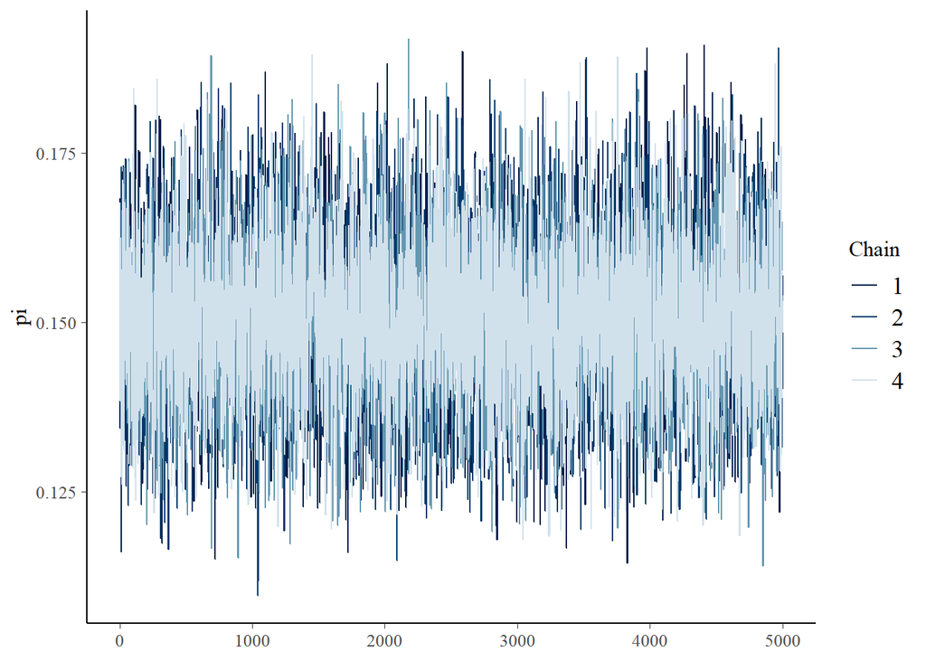

```r
mcmc_trace(climate_sim, pars = "pi", size = .5)
```

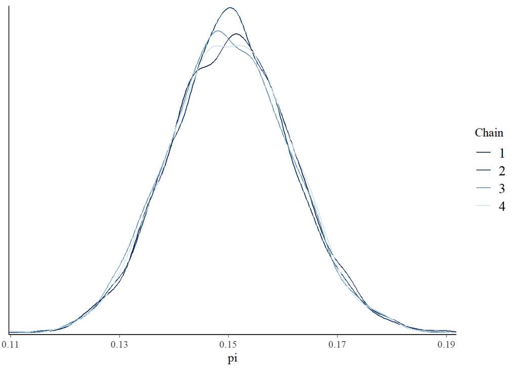

```r
mcmc_dens_overlay(climate_sim, pars = "pi")
```

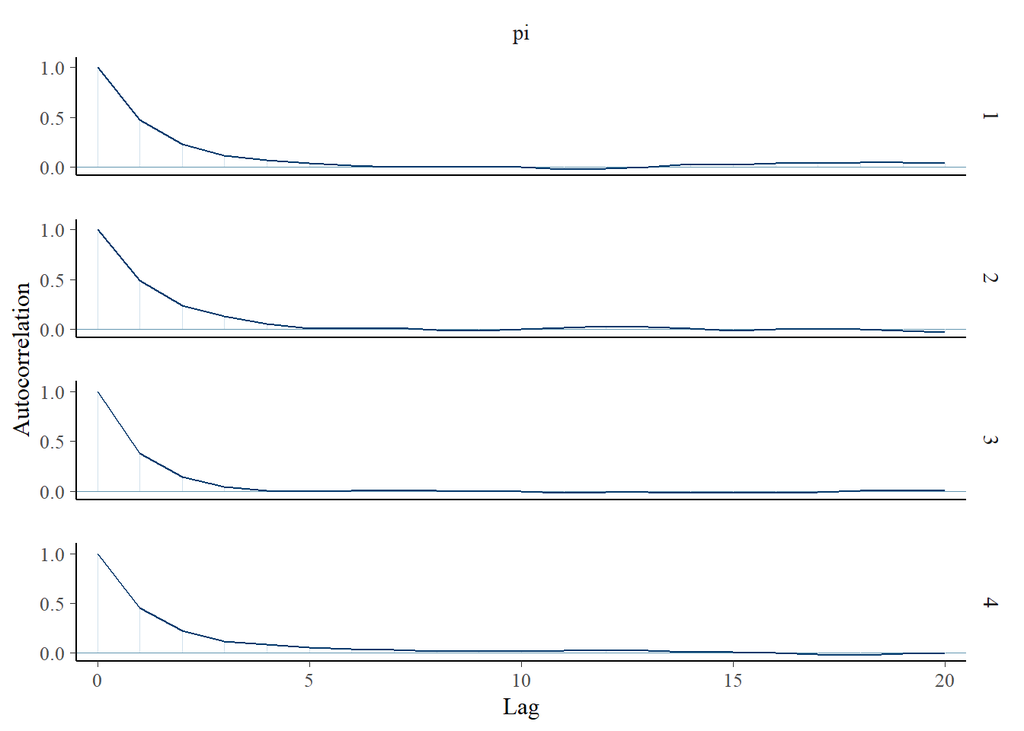

```r
mcmc_acf(climate_sim, pars = "pi")
```

3. Report effective sample size ratio and R-hat values

```r
rhat(climate_sim, pars = "pi")
```

```
## [1] 1.000086
```

```r
neff_ratio(climate_sim, pars = "pi")
```

```
## [1] 0.3548359
```